# Advertisement_Analytics

allan mutisya

1/8/2021

```r
#  locale workaround
my_locale <- Sys.getlocale("LC_ALL")
Sys.setlocale("LC_ALL", my_locale)
```

```
## [1] ""
```

# Advertisement

## 1. Defining the question

### a) Specifying the Question

Identify which individuals are most likely to click on ads the entrepreneur posts

### b) Defining the Metric for Success

The analysis will be considered a success when interactive visulizations that tell a good story are achieved. An all-round Exploratory data analysis is achieved will be considered a success.

### c) Understanding the context

The role of the analysis is to come up with recomendations which the entrepreneur will use to executed in order to identify the fertile areas to first invest on.

### d) Recording the Experimental Design

1. Defining the research question
2. Data Understanding
3. Data cleaning
4. Exploratory Data Analysis
5. Evaluation
6. Conclusion
7. Recommendations

### e) Data Relevance

The datasets are large enough to be used for Exploratory Data Analysis, thus promising better outcomes.

### f) Reading the Data

```r
# loading the dataset
library(readr)
df <- read_csv(file = "C:/Users/ALLANOOH/Documents/moringa/advert_analytics/advert.csv")
library(tidyverse)
my_data <- as_tibble(df)
my_data
```

```
## # A tibble: 1,000 x 10
##    `Daily Time Spe~   Age `Area Income` `Daily Internet~ `Ad Topic Line` City
##               <dbl> <dbl>         <dbl>            <dbl> <chr>           <chr>
##  1             69.0    35        61834.             256. Cloned 5thgene~ Wrig~
##  2             80.2    31        68442.             194. Monitored nati~ West~
##  3             69.5    26        59786.             236. Organic bottom~ Davi~
##  4             74.2    29        54806.             246. Triple-buffere~ West~
##  5             68.4    35        73890.             226. Robust logisti~ Sout~
##  6             60.0    23        59762.             227. Sharable clien~ Jami~
##  7             88.9    33        53853.             208. Enhanced dedic~ Bran~
##  8             66      48        24593.             132. Reactive local~ Port~
##  9             74.5    30        68862              222. Configurable c~ West~
## 10             69.9    20        55642.             184. Mandatory homo~ Rami~
## # ... with 990 more rows, and 4 more variables: Male <dbl>, Country <chr>,
## #   Timestamp <chr>, `Clicked on Ad` <dbl>
```

## 2. Data Understanding

```r
#checking the culumns
ls(df)
```

```
##  [1] "Ad Topic Line"            "Age"
##  [3] "Area Income"              "City"
##  [5] "Clicked on Ad"            "Country"
##  [7] "Daily Internet Usage"     "Daily Time Spent on Site"
##  [9] "Male"                     "Timestamp"
```

```r
# checking the shape of the dataset

my_data
```

```
## # A tibble: 1,000 x 10
##    `Daily Time Spe~   Age `Area Income` `Daily Internet~ `Ad Topic Line` City
##               <dbl> <dbl>         <dbl>            <dbl> <chr>           <chr>
##  1             69.0    35        61834.             256. Cloned 5thgene~ Wrig~
##  2             80.2    31        68442.             194. Monitored nati~ West~
##  3             69.5    26        59786.             236. Organic bottom~ Davi~
##  4             74.2    29        54806.             246. Triple-buffere~ West~
##  5             68.4    35        73890.             226. Robust logisti~ Sout~
##  6             60.0    23        59762.             227. Sharable clien~ Jami~
##  7             88.9    33        53853.             208. Enhanced dedic~ Bran~
##  8             66      48        24593.             132. Reactive local~ Port~
##  9             74.5    30        68862              222. Configurable c~ West~
## 10             69.9    20        55642.             184. Mandatory homo~ Rami~
## # ... with 990 more rows, and 4 more variables: Male <dbl>, Country <chr>,
## #   Timestamp <chr>, `Clicked on Ad` <dbl>
```

The dataset has 1000 rows and 10 columns

## 3. Data cleaning

```r
# Renaming column names where they have spaces in between.
names(my_data)[names(my_data) == "Ad Topic Line"] <- "Ad_Topic_Line"
names(my_data)[names(my_data) == "Clicked on Ad"] <- "Clicked_on_Ad"
names(my_data)[names(my_data) == "Area Income"] <- "Area_Income"
names(my_data)[names(my_data) == "Daily Internet Usage"] <- "Daily_Internet_Usage"
names(my_data)[names(my_data) == "Daily Time Spent on Site"] <- "Daily_Time_Spent_on_Site"
head(my_data)
```

```
## # A tibble: 6 x 10
##   Daily_Time_Spen~   Age Area_Income Daily_Internet_~ Ad_Topic_Line City   Male
##              <dbl> <dbl>       <dbl>            <dbl> <chr>         <chr> <dbl>
## 1             69.0    35      61834.             256. Cloned 5thge~ Wrig~     0
## 2             80.2    31      68442.             194. Monitored na~ West~     1
## 3             69.5    26      59786.             236. Organic bott~ Davi~     0
## 4             74.2    29      54806.             246. Triple-buffe~ West~     1
## 5             68.4    35      73890.             226. Robust logis~ Sout~     0
## 6             60.0    23      59762.             227. Sharable cli~ Jami~     1
## # ... with 3 more variables: Country <chr>, Timestamp <chr>,
## #   Clicked_on_Ad <dbl>
```

```r
# checking for null values
sum(!complete.cases(my_data))
```

```
## [1] 0
```

There are no missing values in the dataset.

```r
# checking for duplicated values
sum(duplicated(my_data))
```

```
## [1] 0
```

There are no dupicated values in the dataset.

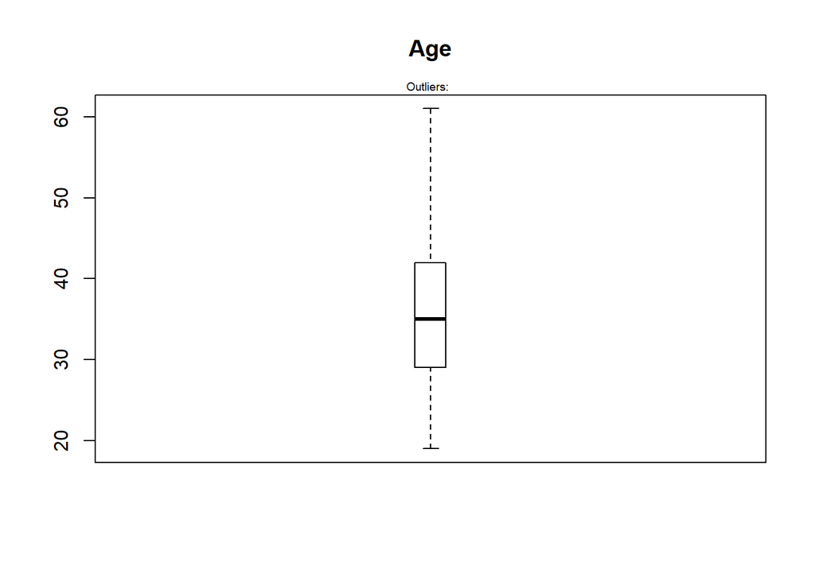

```r
# Outlier detection for the Age column
outlier_values <- boxplot.stats(my_data$Age)$out  # outlier values.
boxplot(my_data$Age, main="Age", boxwex=0.1)
mtext(paste("Outliers: ", paste(outlier_values, collapse=", ")), cex=0.6)
```

There were no outliers detected for the age column

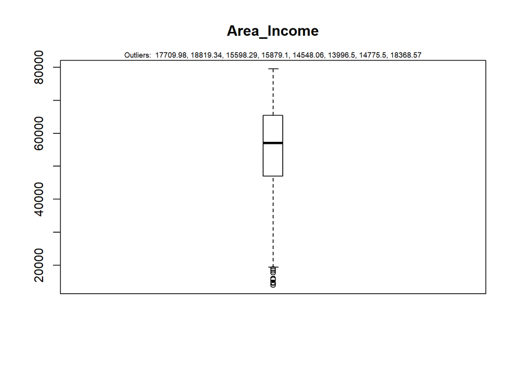

```r
# Outlier detection for the Area_Incomecolumn
outlier_values <- boxplot.stats(my_data$Area_Income)$out  # outlier values.
boxplot(my_data$Area_Income, main="Area_Income", boxwex=0.1)
mtext(paste("Outliers: ", paste(outlier_values, collapse=", ")), cex=0.6)
```

```r
# removing the outliers in the Area_income column
Q <- quantile(my_data$Area_Income, probs=c(.25, .75), na.rm = FALSE)
iqr <- IQR(my_data$Area_Income)
up <-  Q[2]+1.5*iqr # Upper Range
low<- Q[1]-1.5*iqr # Lower Range
eliminated<- subset(my_data, my_data$Area_Income > (Q[1] - 1.5*iqr) & my_data$Area_Income < (Q[2]+1.5*iqr))

eliminated
```

```
## # A tibble: 991 x 10
##    Daily_Time_Spen~   Age Area_Income Daily_Internet_~ Ad_Topic_Line City   Male
##               <dbl> <dbl>       <dbl>            <dbl> <chr>         <chr> <dbl>
##  1             69.0    35      61834.             256. Cloned 5thge~ Wrig~     0
##  2             80.2    31      68442.             194. Monitored na~ West~     1
##  3             69.5    26      59786.             236. Organic bott~ Davi~     0
##  4             74.2    29      54806.             246. Triple-buffe~ West~     1
##  5             68.4    35      73890.             226. Robust logis~ Sout~     0
##  6             60.0    23      59762.             227. Sharable cli~ Jami~     1
##  7             88.9    33      53853.             208. Enhanced ded~ Bran~     0
##  8             66      48      24593.             132. Reactive loc~ Port~     1
##  9             74.5    30      68862              222. Configurable~ West~     1
## 10             69.9    20      55642.             184. Mandatory ho~ Rami~     1
## # ... with 981 more rows, and 3 more variables: Country <chr>, Timestamp <chr>,
## #   Clicked_on_Ad <dbl>
```

There were several outliers detected on the Area _income column and removed

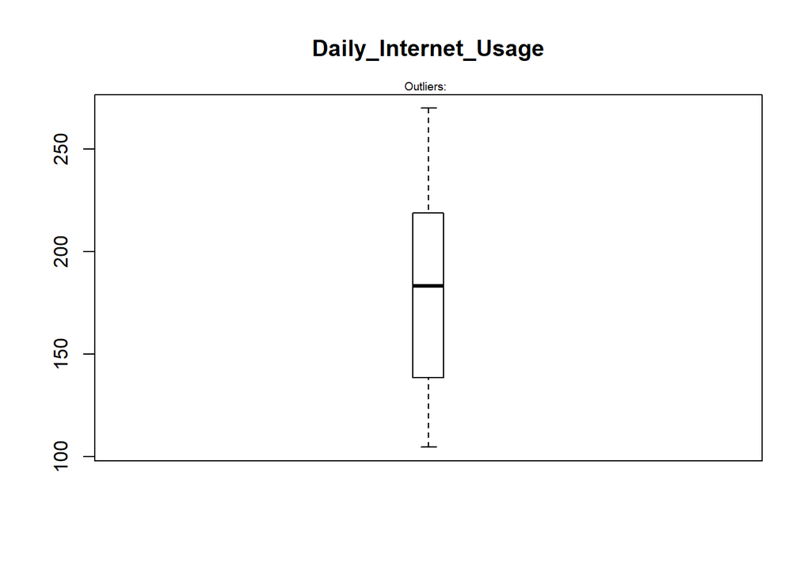

```r
# Outlier detection for the Daily_Internet_Usage
outlier_values <- boxplot.stats(eliminated$Daily_Internet_Usage)$out  # outlier values.
boxplot(eliminated$Daily_Internet_Usage, main="Daily_Internet_Usage", boxwex=0.1)
mtext(paste("Outliers: ", paste(outlier_values, collapse=", ")), cex=0.6)
```

There were no outliers for the daily internet usage

```r
# Cheking the dataset shape after cleaning.
eliminated
```

```
## # A tibble: 991 x 10
##    Daily_Time_Spen~   Age Area_Income Daily_Internet_~ Ad_Topic_Line City   Male
##               <dbl> <dbl>       <dbl>            <dbl> <chr>         <chr> <dbl>
##  1             69.0    35      61834.             256. Cloned 5thge~ Wrig~     0
##  2             80.2    31      68442.             194. Monitored na~ West~     1
##  3             69.5    26      59786.             236. Organic bott~ Davi~     0
##  4             74.2    29      54806.             246. Triple-buffe~ West~     1
##  5             68.4    35      73890.             226. Robust logis~ Sout~     0
##  6             60.0    23      59762.             227. Sharable cli~ Jami~     1
##  7             88.9    33      53853.             208. Enhanced ded~ Bran~     0
##  8             66      48      24593.             132. Reactive loc~ Port~     1
##  9             74.5    30      68862              222. Configurable~ West~     1
## 10             69.9    20      55642.             184. Mandatory ho~ Rami~     1
## # ... with 981 more rows, and 3 more variables: Country <chr>, Timestamp <chr>,
## #   Clicked_on_Ad <dbl>
```

After cleaning the dataset there are 991 rows and 10 columns left.

## 4. Exploratory data Analysis

### Univariate Analysis.

#### a) Daily time spend on site

##### i) Measures of Central Tendency

```r
# checking for the mean
mean(eliminated$Daily_Time_Spent_on_Site)
```

```
## [1] 65.05689
```

```r
# checking for the median
median(eliminated$Daily_Time_Spent_on_Site)
```

```
## [1] 68.41
```

```r
# checking for the mode
getmode <- function(v) {
   uniqv <- unique(v)
   uniqv[which.max(tabulate(match(v, uniqv)))]
}
getmode(eliminated$Daily_Time_Spent_on_Site)
```

```
## [1] 62.26
```

##### ii) measures of dispersion

```r
# checking for the variance
var(eliminated$Daily_Time_Spent_on_Site)
```

```
## [1] 252.8258
```

```r
# checking for the standard deviation
sd(eliminated$Daily_Time_Spent_on_Site)
```

```
## [1] 15.9005
```

```r
# checking for the minimum value
min(eliminated$Daily_Time_Spent_on_Site)
```

```
## [1] 32.6
```

```r
# checking for the maximum value
max(eliminated$Daily_Time_Spent_on_Site)
```

```
## [1] 91.43
```

```r
# checking for the range
range(eliminated$Daily_Time_Spent_on_Site)
```

```
## [1] 32.60 91.43
```

```r
# checking for the quantile
quantile(eliminated$Daily_Time_Spent_on_Site)
```

```
##    0%   25%   50%   75%  100%
## 32.60 51.34 68.41 78.59 91.43
```

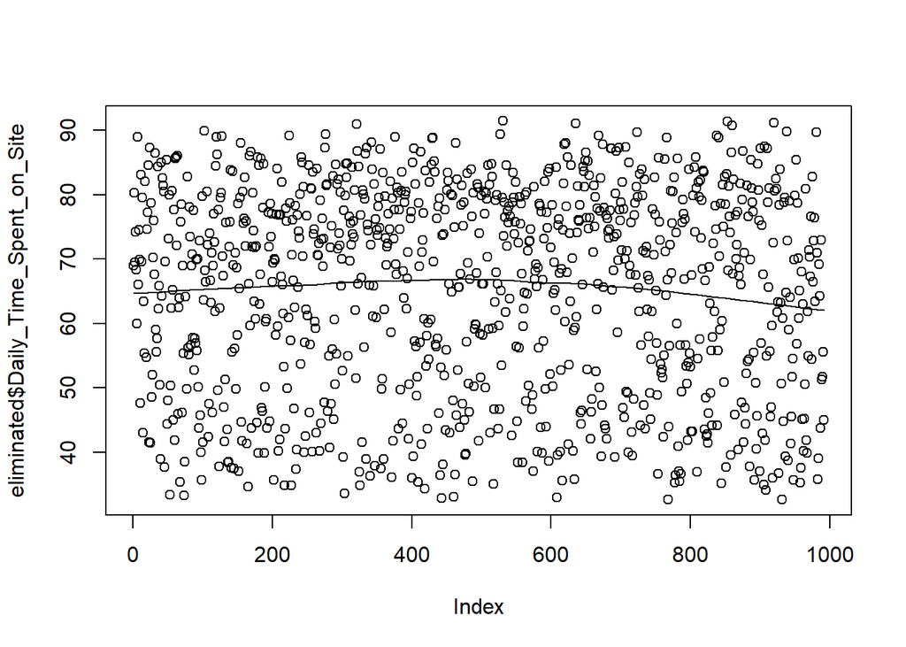

```r
# plotting for the daily time spend on site
scatter.smooth(eliminated$Daily_Time_Spent_on_Site)
```

The daily time spend on dite is scattered it does not exhibit a unique character such as clustering at specific times.

#### b) Age

##### i) Measures of Central Tendency

```r
# checking for the mean
mean(eliminated$Age)
```

```
## [1] 35.98587
```

```r
# checking for the median
median(eliminated$Age)
```

```
## [1] 35
```

```r
# checking for the mode
getmode <- function(v) {
   uniqv <- unique(v)
   uniqv[which.max(tabulate(match(v, uniqv)))]
}
getmode(eliminated$Age)
```

```
## [1] 31
```

##### ii) measures of dispersion

```r
# checking for the variance
var(eliminated$Age)
```

```
## [1] 77.52303
```

```r
# checking for the standard deviation
sd(eliminated$Age)
```

```
## [1] 8.804716
```

```r
# checking for the minimum value
min(eliminated$Age)
```

```
## [1] 19
```

```r
# checking for the maximum value
max(eliminated$Age)
```

```
## [1] 61
```

```r
# checking for the range
range(eliminated$Age)
```

```
## [1] 19 61
```

```r
# checking for the quantile
quantile(eliminated$Age)
```

```
##   0%  25%  50%  75% 100%
##   19   29   35   42   61
```

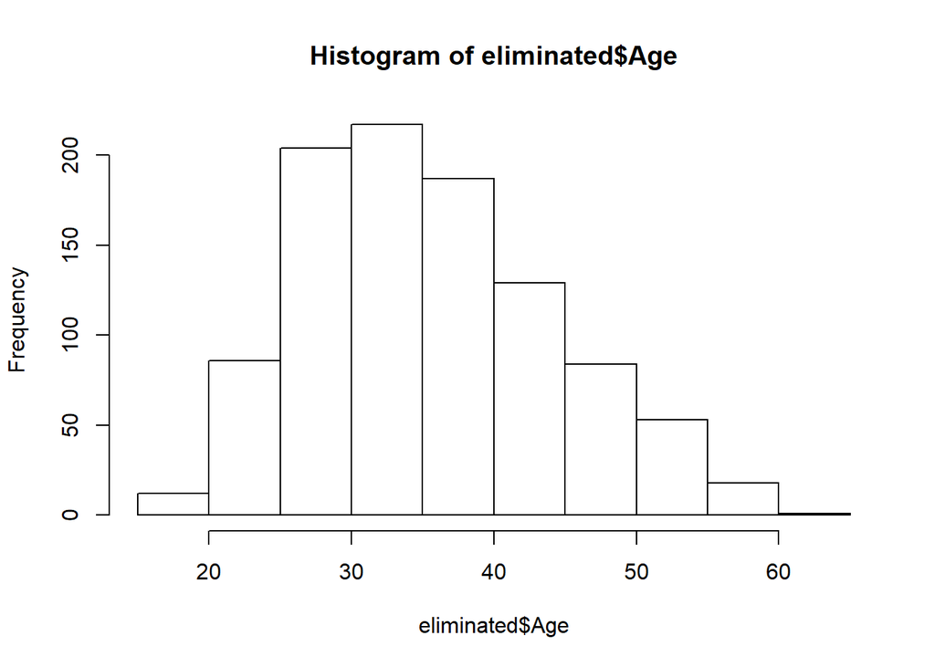

```r
# plotting histogram for the Age column
hist(eliminated$Age)
```

The Age of the respondents was mostly between 25 to 45 years

#### c) Area income

##### i) Measures of Central Tendency

```r
# checking for the mean
mean(eliminated$Area_Income)
```

```
## [1] 55349.1
```

```r
# checking for the median
median(eliminated$Area_Income)
```

```
## [1] 57260.41
```

```r
# checking for the mode
getmode <- function(v) {
   uniqv <- unique(v)
   uniqv[which.max(tabulate(match(v, uniqv)))]
}
getmode(eliminated$Area_Income)
```

```
## [1] 61833.9
```

##### ii) measures of dispersion

```r
# checking for the variance
var(eliminated$Area_Income)
```

```
## [1] 168000385
```

```r
# checking for the standard deviation
sd(eliminated$Area_Income)
```

```
## [1] 12961.5
```

```r
# checking for the minimum value
min(eliminated$Area_Income)
```

```
## [1] 19991.72
```

```r
# checking for the maximum value
max(eliminated$Area_Income)
```

```
## [1] 79484.8
```

```r
# checking for the range
range(eliminated$Area_Income)
```

```
## [1] 19991.72 79484.80
```

```r
# checking for the quantile
quantile(eliminated$Area_Income)
```

```
##       0%      25%      50%      75%     100%
## 19991.72 47348.17 57260.41 65537.99 79484.80
```

[figure not shown]

```r
# plotting for the area income
library(ggplot2)
library(ggpubr)
theme_set(theme_pubr())
ggplot(eliminated, aes(Area_Income)) +
  geom_bar(fill = "#0073C2FF") +
  theme_pubclean()
```

#### c) Daily internet usage

##### i) Measures of Central Tendency

```r
# checking for the mean
mean(eliminated$Daily_Internet_Usage)
```

```
## [1] 179.9846
```

```r
# checking for the median
median(eliminated$Daily_Internet_Usage)
```

```
## [1] 183.43
```

```r
# checking for the mode
getmode <- function(v) {
   uniqv <- unique(v)
   uniqv[which.max(tabulate(match(v, uniqv)))]
}
getmode(eliminated$Daily_Internet_Usage)
```

```
## [1] 167.22
```

##### ii) measures of dispersion

```r
# checking for the variance
var(eliminated$Daily_Internet_Usage)
```

```
## [1] 1940.743
```

```r
# checking for the standard deviation
sd(eliminated$Daily_Internet_Usage)
```

```
## [1] 44.05386
```

```r
# checking for the minimum value
min(eliminated$Daily_Internet_Usage)
```

```
## [1] 104.78
```

```r
# checking for the maximum value
max(eliminated$Daily_Internet_Usage)
```

```
## [1] 269.96
```

```r
# checking for the range
range(eliminated$Daily_Internet_Usage)
```

```
## [1] 104.78 269.96
```

```r
# checking for the quantile
quantile(eliminated$Daily_Internet_Usage)
```

```
##      0%     25%     50%     75%    100%
## 104.780 138.615 183.430 218.885 269.960
```

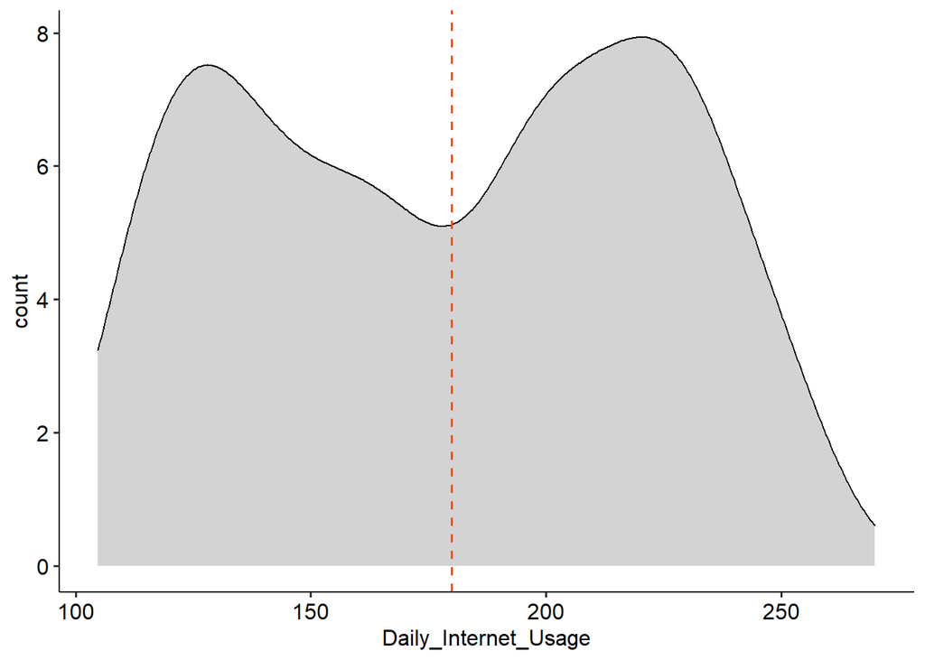

```r
# plotting for the Daily_Internet_Usage
a <- ggplot(eliminated, aes(x = Daily_Internet_Usage))
a + geom_density(aes(y = ..count..), fill = "lightgray") +
  geom_vline(aes(xintercept = mean(Daily_Internet_Usage)),
             linetype = "dashed", size = 0.6,
             color = "#FC4E07")
```

Most of the respodents their daily internet usage is above 175 (the mean value)

#### d) Gender

##### i) Measures of Central Tendency

```r
# checking for the mean
mean(eliminated$Male)
```

```
## [1] 0.4793138
```

```r
# checking for the median
median(eliminated$Male)
```

```
## [1] 0
```

```r
# checking for the mode
getmode <- function(v) {
   uniqv <- unique(v)
   uniqv[which.max(tabulate(match(v, uniqv)))]
}
getmode(eliminated$Male)
```

```
## [1] 0
```

##### ii) measures of dispersion

```r
# checking for the variance
var(eliminated$Male)
```

```
## [1] 0.2498242
```

```r
# checking for the standard deviation
sd(eliminated$Male)
```

```
## [1] 0.4998241
```

```r
# checking for the minimum value
min(eliminated$Male)
```

```
## [1] 0
```

```r
# checking for the maximum value
max(eliminated$Male)
```

```
## [1] 1
```

```r
# checking for the range
range(eliminated$Male)
```

```
## [1] 0 1
```

```r
# checking for the quantile
quantile(eliminated$Male)
```

```
##   0%  25%  50%  75% 100%
##    0    0    0    1    1
```

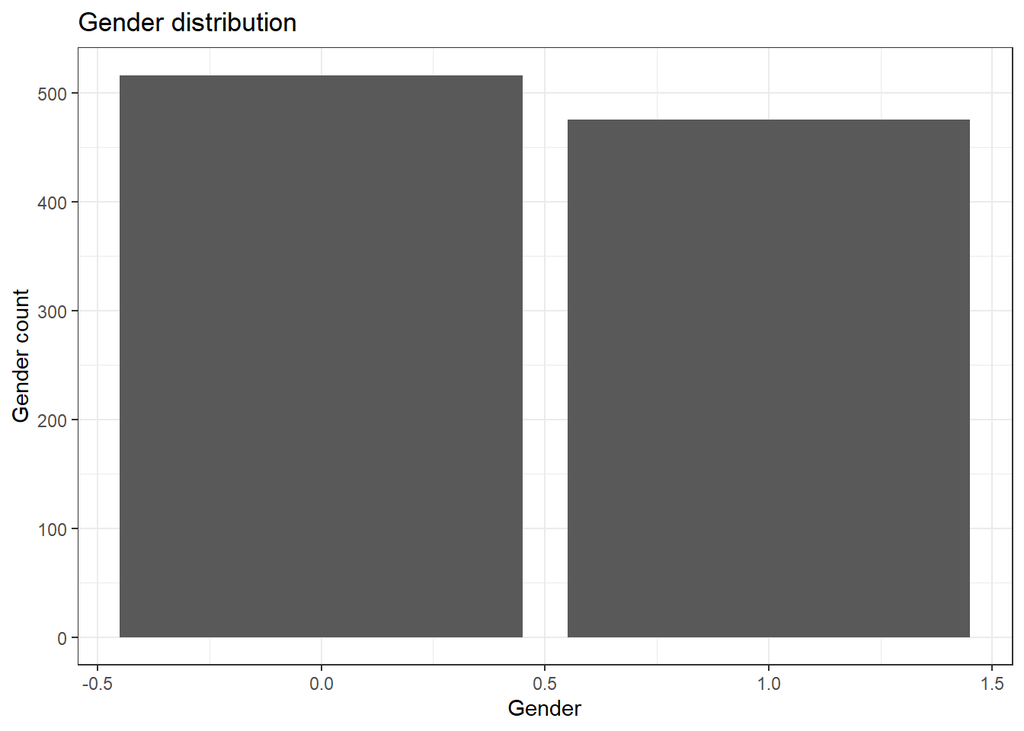

```r
# plotting for the gender distribution
ggplot(eliminated, aes(x = Male)) +
  geom_bar() + theme_bw() +
  labs(y = "Gender count", x = "Gender", title = "Gender distribution")
```

The most respodents were the females represented by 0 as shown in the graph above

#### e) clicked on add

##### i) Measures of Central Tendency

```r
# checking for the mean
mean(eliminated$Clicked_on_Ad)
```

```
## [1] 0.4954591
```

```r
# checking for the median
median(eliminated$Clicked_on_Ad)
```

```
## [1] 0
```

```r
# checking for the mode
getmode <- function(v) {
   uniqv <- unique(v)
   uniqv[which.max(tabulate(match(v, uniqv)))]
}
getmode(eliminated$Clicked_on_Ad)
```

```
## [1] 0
```

##### ii) measures of dispersion

```r
# checking for the variance
var(eliminated$Clicked_on_Ad)
```

```
## [1] 0.2502319
```

```r
# checking for the standard deviation
sd(eliminated$Clicked_on_Ad)
```

```
## [1] 0.5002318
```

```r
# checking for the minimum value
min(eliminated$Clicked_on_Ad)
```

```
## [1] 0
```

```r
# checking for the maximum value
max(eliminated$Clicked_on_Ad)
```

```
## [1] 1
```

```r
# checking for the range
range(eliminated$Clicked_on_Ad)
```

```
## [1] 0 1
```

```r
# checking for the quantile
quantile(eliminated$Clicked_on_Ad)
```

```
##   0%  25%  50%  75% 100%
##    0    0    0    1    1
```

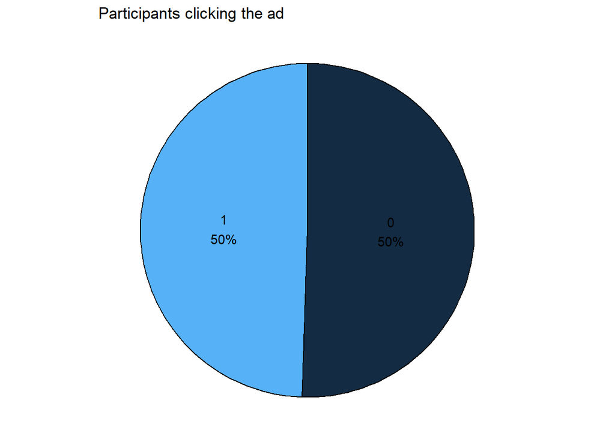

```r
# create a pie chart with slice labels
plotdata <- eliminated %>%
  count(Clicked_on_Ad) %>%
  arrange(desc(Clicked_on_Ad)) %>%
  mutate(prop = round(n*100/sum(n), 1),
         lab.ypos = cumsum(prop) - 0.5*prop)

plotdata$label <- paste0(plotdata$Clicked_on_Ad, "\n",
                         round(plotdata$prop), "%")

ggplot(plotdata,
       aes(x = "",
           y = prop,
           fill = Clicked_on_Ad)) +
  geom_bar(width = 1,
           stat = "identity",
           color = "black") +
  geom_text(aes(y = lab.ypos, label = label),
            color = "black") +
  coord_polar("y",
              start = 0,
              direction = -1) +
  theme_void() +
  theme(legend.position = "FALSE") +
  labs(title = "Participants clicking the ad")
```

The distristribution of the participants clicking the ad is 50% to 50%

#### f) Country

```r
# Compute the frequency
library(dplyr)
df <- eliminated %>%
  group_by(Country) %>%
  summarise(counts = n())
df
```

```
## # A tibble: 237 x 2
##    Country                                      counts
##    <chr>                                         <int>
##  1 Afghanistan                                       8
##  2 Albania                                           7
##  3 Algeria                                           5
##  4 American Samoa                                    5
##  5 Andorra                                           2
##  6 Angola                                            4
##  7 Anguilla                                          6
##  8 Antarctica (the territory South of 60 deg S)      3
##  9 Antigua and Barbuda                               5
## 10 Argentina                                         2
## # ... with 227 more rows
```

### Bivariate Analysis.

#### Overal correlation matrix

```r
x = subset(eliminated, select = -c(Ad_Topic_Line, City, Country, Timestamp))
x
```

```
## # A tibble: 991 x 6
##    Daily_Time_Spent_on~   Age Area_Income Daily_Internet_Us~  Male Clicked_on_Ad
##                   <dbl> <dbl>       <dbl>              <dbl> <dbl>         <dbl>
##  1                 69.0    35      61834.               256.     0             0
##  2                 80.2    31      68442.               194.     1             0
##  3                 69.5    26      59786.               236.     0             0
##  4                 74.2    29      54806.               246.     1             0
##  5                 68.4    35      73890.               226.     0             0
##  6                 60.0    23      59762.               227.     1             0
##  7                 88.9    33      53853.               208.     0             0
##  8                 66      48      24593.               132.     1             1
##  9                 74.5    30      68862                222.     1             0
## 10                 69.9    20      55642.               184.     1             0
## # ... with 981 more rows
```

```r
cor(x, method = "pearson", use = "complete.obs")
```

```
##                          Daily_Time_Spent_on_Site         Age Area_Income
## Daily_Time_Spent_on_Site               1.00000000 -0.33285145  0.31345211
## Age                                   -0.33285145  1.00000000 -0.18177184
## Area_Income                            0.31345211 -0.18177184  1.00000000
## Daily_Internet_Usage                   0.52003198 -0.36795375  0.35221300
## Male                                  -0.01997511 -0.02416672  0.01199546
## Clicked_on_Ad                         -0.74911960  0.49329383 -0.47021067
##                          Daily_Internet_Usage        Male Clicked_on_Ad
## Daily_Time_Spent_on_Site           0.52003198 -0.01997511   -0.74911960
## Age                               -0.36795375 -0.02416672    0.49329383
## Area_Income                        0.35221300  0.01199546   -0.47021067
## Daily_Internet_Usage               1.00000000  0.02773955   -0.79134386
## Male                               0.02773955  1.00000000   -0.04178558
## Clicked_on_Ad                     -0.79134386 -0.04178558    1.00000000
```

#### a) Daily time spend on the site and the age

##### i) Covariance

```r
d <- eliminated$Daily_Time_Spent_on_Site
e <- eliminated$Age
cov(d, e)
```

```
## [1] -46.59899
```

The covariance of dailytie spend on site is about -46.59899. It indicates a nwgative linear relationship between the two variables. That is, as one increases the one decreases. for example if age increase the daily spent time on side reduces

##### ii) correlation

```r
cor(d, e)
```

```
## [1] -0.3328515
```

The correlation coefficient of daily spent time and age is -0.3328515.we can conclude that the variables are negatively linearly related.

##### iii) plot of age and daily time spent on site

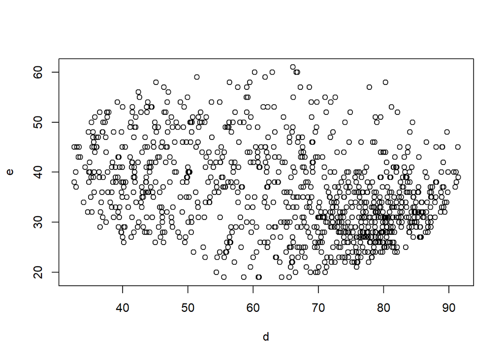

```r
plot(d, e)
```

#### b) Age and rate of clicking the ad

##### i) covariance

```r
cov(eliminated$Age, eliminated$Clicked_on_Ad)
```

```
## [1] 2.172663
```

The covariance of age and clicking the ad is about 2.172663. It indicates a positive linear relationship between the two variables. Thus if one increases the other also increases. For example, if the age increases the probability id high that the respodent will click the ad

##### ii) correlation

```r
cor(eliminated$Age, eliminated$Clicked_on_Ad)
```

```
## [1] 0.4932938
```

we can conclude that the variables are positively linearly related.

##### iii) plot

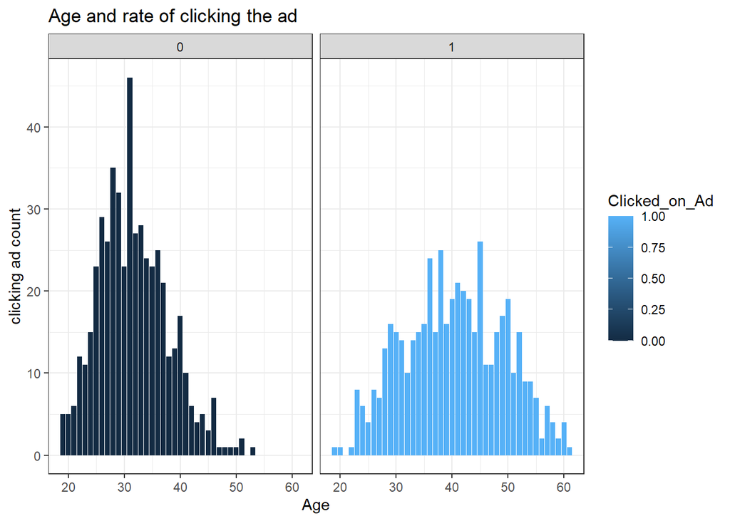

```r
ggplot(eliminated, aes(x = Age, fill = Clicked_on_Ad)) +
  facet_wrap(~ Clicked_on_Ad) +
  theme_bw() +
  geom_bar() +
  labs(y = "clicking ad count", title = "Age and rate of clicking the ad")
```

As we can observe the ad was mostly clicked by the order people unlike the young people

#### c) Gender that mostly clicked

##### i) covariance

```r
cov(eliminated$Male, eliminated$Clicked_on_Ad)
```

```
## [1] -0.01044756
```

There is a negative relationship between the gender and the rate of clicking the ad

##### ii) correlation

```r
cor(eliminated$Male, eliminated$Clicked_on_Ad)
```

```
## [1] -0.04178558
```

There is a weak negative reltionship between the two

##### iii) plot

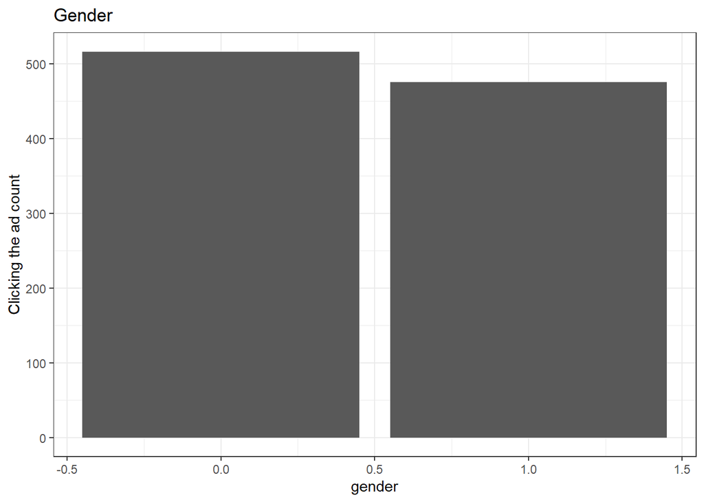

```r
ggplot(eliminated, aes(x = Male, fill = Clicked_on_Ad)) +
  theme_bw() + geom_bar() +
  labs(y = "Clicking the ad count", x = 'gender', title = "Gender")
```

Most females clicked the ad compared to males